# Statistical Inference Course Project - Part 1

Pavit Masson

February 9, 2019

## Overview

The purpose of this project is to investigate the exponential distribution in R and compare it with the Central Limit Theorem. The exponential distribution will be simulated in R with rexp(n, lambda), where lambda is the rate parameter. The mean of the exponential distribution is 1/lambda and the standard deviation is also 1/lambda. Lambda = 0.2 for all simulations.

In this project, I will investigate the distribution of averages of 40 exponentials and do 1,000 simulations.

## Simulations

First we will set up the simulation parameters.

```r
set.seed(1111)
lambda = 0.2
n = 40
```

Next, we will run the simulations and calculate the means.

```r
sims <- replicate(1000, rexp(n, lambda))
sims_means <- apply(sims, 2, mean)
```

## Sample Mean vs. Theoretical Mean

The sample mean is the mean of the simulation means, and is calculated and graphically shown below:

```r
sample_mean <- mean(sims_means)
sample_mean
```

```
## [1] 4.994883
```

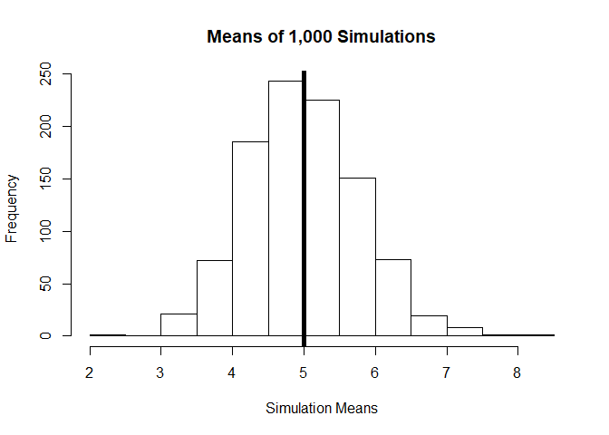

```r
hist(sims_means, main = "Means of 1,000 Simulations", xlab = "Simulation Means")
abline(v = sample_mean, lwd = 5)
```

The sample mean is shown as the thick line.

The theoretical mean is 1/lambda.

```r
theo_mean <- 1/lambda
theo_mean
```

```
## [1] 5
```

So, the difference between the sample mean and theoretical mean is

```r
abs(sample_mean - theo_mean)
```

```
## [1] 0.005117261
```

We can see that the sample mean is very close to the theoretical mean.

## Sample Variance vs. Theoretical Variance

The sample variance is calculated below.

```r
sample_var <- var(sims_means)
sample_var
```

```
## [1] 0.6105269
```

The theoretical variance is equal to [(1/lambda)/sqrt(n)]^2.

```r
theo_var <- ((1/lambda)/sqrt(n))^2
theo_var
```

```
## [1] 0.625
```

So, the difference between the sample variance and theoretical variance is

```r
abs(sample_var - theo_var)
```

```
## [1] 0.0144731
```

We can see from the above that both the sample and theoretical variance are close to 0.6.

## Distribution

In order to quickly tell if the distribution is normal, we can plot the means on a histogram and see if the overall shape resembles that of the normal distribution bell curve.

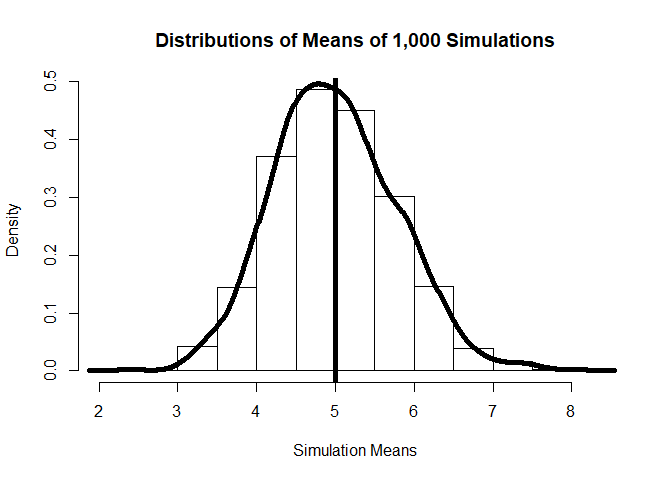

```r
hist(sims_means, prob = TRUE, main = "Distributions of Means of 1,000 Simulations", xlab = "Simulation Means")
abline(v = sample_mean, lwd = 5)
lines(density(sims_means), lwd = 5)
```